# Prosper Loan Dataset

This data set contains 113,937 loans with 81 variables on each loan, including loan amount, borrower rate (or interest rate), current loan status, borrower income, and many others. This data dictionary explains the variables in the data set. You are not expected to explore all of the variables in the dataset! Focus your exploration on about 10-15 of them.

### Main Project Questions:

- What factors affect a loan’s outcome status?
- What affects the borrower’s APR or interest rate?
- Are there differences between loans depending on how large the original loan amount was?

## Note to Reviewer:

This project is done by Meisam Heidari and I together.

## Dataset Overview(Programatic)

```python
df_loan = pd.read_csv('prosperLoanData.csv')
```

```python
df_loan.head()
```

|  | ListingKey | ListingNumber | ListingCreationDate | CreditGrade | Term | LoanStatus | ClosedDate | BorrowerAPR | BorrowerRate | LenderYield | ... | LP_ServiceFees | LP_CollectionFees | LP_GrossPrincipalLoss | LP_NetPrincipalLoss | LP_NonPrincipalRecoverypayments | PercentFunded | Recommendations | InvestmentFromFriendsCount | InvestmentFromFriendsAmount | Investors |
| --- | --- | --- | --- | --- | --- | --- | --- | --- | --- | --- | --- | --- | --- | --- | --- | --- | --- | --- | --- | --- | --- |
| 0 | 1021339766868145413AB3B | 193129 | 2007-08-26 19:09:29.263000000 | C | 36 | Completed | 2009-08-14 00:00:00 | 0.16516 | 0.1580 | 0.1380 | ... | -133.18 | 0.0 | 0.0 | 0.0 | 0.0 | 1.0 | 0 | 0 | 0.0 | 258 |
| 1 | 10273602499503308B223C1 | 1209647 | 2014-02-27 08:28:07.900000000 | NaN | 36 | Current | NaN | 0.12016 | 0.0920 | 0.0820 | ... | 0.00 | 0.0 | 0.0 | 0.0 | 0.0 | 1.0 | 0 | 0 | 0.0 | 1 |
| 2 | 0EE9337825851032864889A | 81716 | 2007-01-05 15:00:47.090000000 | HR | 36 | Completed | 2009-12-17 00:00:00 | 0.28269 | 0.2750 | 0.2400 | ... | -24.20 | 0.0 | 0.0 | 0.0 | 0.0 | 1.0 | 0 | 0 | 0.0 | 41 |
| 3 | 0EF5356002482715299901A | 658116 | 2012-10-22 11:02:35.010000000 | NaN | 36 | Current | NaN | 0.12528 | 0.0974 | 0.0874 | ... | -108.01 | 0.0 | 0.0 | 0.0 | 0.0 | 1.0 | 0 | 0 | 0.0 | 158 |
| 4 | 0F023589499656230C5E3E2 | 909464 | 2013-09-14 18:38:39.097000000 | NaN | 36 | Current | NaN | 0.24614 | 0.2085 | 0.1985 | ... | -60.27 | 0.0 | 0.0 | 0.0 | 0.0 | 1.0 | 0 | 0 | 0.0 | 20 |

5 rows × 81 columns

```python
df_loan.describe()
```

|  | ListingNumber | Term | BorrowerAPR | BorrowerRate | LenderYield | EstimatedEffectiveYield | EstimatedLoss | EstimatedReturn | ProsperRating (numeric) | ProsperScore | ... | LP_ServiceFees | LP_CollectionFees | LP_GrossPrincipalLoss | LP_NetPrincipalLoss | LP_NonPrincipalRecoverypayments | PercentFunded | Recommendations | InvestmentFromFriendsCount | InvestmentFromFriendsAmount | Investors |
| --- | --- | --- | --- | --- | --- | --- | --- | --- | --- | --- | --- | --- | --- | --- | --- | --- | --- | --- | --- | --- | --- |
| count | 1.139370e+05 | 113937.000000 | 113912.000000 | 113937.000000 | 113937.000000 | 84853.000000 | 84853.000000 | 84853.000000 | 84853.000000 | 84853.000000 | ... | 113937.000000 | 113937.000000 | 113937.000000 | 113937.000000 | 113937.000000 | 113937.000000 | 113937.000000 | 113937.000000 | 113937.000000 | 113937.000000 |
| mean | 6.278857e+05 | 40.830248 | 0.218828 | 0.192764 | 0.182701 | 0.168661 | 0.080306 | 0.096068 | 4.072243 | 5.950067 | ... | -54.725641 | -14.242698 | 700.446342 | 681.420499 | 25.142686 | 0.998584 | 0.048027 | 0.023460 | 16.550751 | 80.475228 |
| std | 3.280762e+05 | 10.436212 | 0.080364 | 0.074818 | 0.074516 | 0.068467 | 0.046764 | 0.030403 | 1.673227 | 2.376501 | ... | 60.675425 | 109.232758 | 2388.513831 | 2357.167068 | 275.657937 | 0.017919 | 0.332353 | 0.232412 | 294.545422 | 103.239020 |
| min | 4.000000e+00 | 12.000000 | 0.006530 | 0.000000 | -0.010000 | -0.182700 | 0.004900 | -0.182700 | 1.000000 | 1.000000 | ... | -664.870000 | -9274.750000 | -94.200000 | -954.550000 | 0.000000 | 0.700000 | 0.000000 | 0.000000 | 0.000000 | 1.000000 |
| 25% | 4.009190e+05 | 36.000000 | 0.156290 | 0.134000 | 0.124200 | 0.115670 | 0.042400 | 0.074080 | 3.000000 | 4.000000 | ... | -73.180000 | 0.000000 | 0.000000 | 0.000000 | 0.000000 | 1.000000 | 0.000000 | 0.000000 | 0.000000 | 2.000000 |
| 50% | 6.005540e+05 | 36.000000 | 0.209760 | 0.184000 | 0.173000 | 0.161500 | 0.072400 | 0.091700 | 4.000000 | 6.000000 | ... | -34.440000 | 0.000000 | 0.000000 | 0.000000 | 0.000000 | 1.000000 | 0.000000 | 0.000000 | 0.000000 | 44.000000 |
| 75% | 8.926340e+05 | 36.000000 | 0.283810 | 0.250000 | 0.240000 | 0.224300 | 0.112000 | 0.116600 | 5.000000 | 8.000000 | ... | -13.920000 | 0.000000 | 0.000000 | 0.000000 | 0.000000 | 1.000000 | 0.000000 | 0.000000 | 0.000000 | 115.000000 |
| max | 1.255725e+06 | 60.000000 | 0.512290 | 0.497500 | 0.492500 | 0.319900 | 0.366000 | 0.283700 | 7.000000 | 11.000000 | ... | 32.060000 | 0.000000 | 25000.000000 | 25000.000000 | 21117.900000 | 1.012500 | 39.000000 | 33.000000 | 25000.000000 | 1189.000000 |

8 rows × 61 columns

```python
df_loan.LoanStatus.unique()
```

```
array(['Completed', 'Current', 'Past Due (1-15 days)', 'Defaulted',
       'Chargedoff', 'Past Due (16-30 days)', 'Cancelled',
       'Past Due (61-90 days)', 'Past Due (31-60 days)',
       'Past Due (91-120 days)', 'FinalPaymentInProgress',
       'Past Due (>120 days)'], dtype=object)
```

### Basic Cleaning:

Our main goal for cleaning is to enable the plotting libraries plot the data without problems. It is also imparative to remove bad/missing data to avoid misleading plots.

**Define:**

- change EmploymentStatus from nan to 'Not Available'
- change IncomeRange from Not Employed to $0
- TotalCreditLinespast7years type is float, change to integer
- BorrowerAPR contains 25 NaN values which limits plotting capabilities, should be dropped

**Code:**

```python
df_loan.EmploymentStatus.fillna(value = 'Not available', inplace = True)
```

```python
df_loan.IncomeRange.replace('Not employed', '$0', inplace = True)
```

```python
df_loan.TotalCreditLinespast7years = df_loan.TotalCreditLinespast7years.astype('Int64')
```

```python
df_loan.dropna(subset=['BorrowerAPR'], inplace=True)
```

## Test

```python
df_loan.EmploymentStatus.unique()
```

```
array(['Self-employed', 'Employed', 'Not available', 'Full-time', 'Other',
       'Not employed', 'Part-time', 'Retired'], dtype=object)
```

```python
df_loan.IncomeRange.unique()
```

```
array(['$25,000-49,999', '$50,000-74,999', 'Not displayed', '$100,000+',
       '$75,000-99,999', '$1-24,999', '$0'], dtype=object)
```

```python
df_loan.info()
```

```
<class 'pandas.core.frame.DataFrame'>
Int64Index: 113912 entries, 0 to 113936
Data columns (total 81 columns):
ListingKey                             113912 non-null object
ListingNumber                          113912 non-null int64
ListingCreationDate                    113912 non-null object
CreditGrade                            28928 non-null object
Term                                   113912 non-null int64
LoanStatus                             113912 non-null object
ClosedDate                             55064 non-null object
BorrowerAPR                            113912 non-null float64
BorrowerRate                           113912 non-null float64
LenderYield                            113912 non-null float64
EstimatedEffectiveYield                84853 non-null float64
EstimatedLoss                          84853 non-null float64
EstimatedReturn                        84853 non-null float64
ProsperRating (numeric)                84853 non-null float64
ProsperRating (Alpha)                  84853 non-null object
ProsperScore                           84853 non-null float64
ListingCategory (numeric)              113912 non-null int64
BorrowerState                          108422 non-null object
Occupation                             110349 non-null object
EmploymentStatus                       113912 non-null object
EmploymentStatusDuration               106312 non-null float64
IsBorrowerHomeowner                    113912 non-null bool
CurrentlyInGroup                       113912 non-null bool
GroupKey                               13323 non-null object
DateCreditPulled                       113912 non-null object
CreditScoreRangeLower                  113346 non-null float64
CreditScoreRangeUpper                  113346 non-null float64
FirstRecordedCreditLine                113240 non-null object
CurrentCreditLines                     106333 non-null float64
OpenCreditLines                        106333 non-null float64
TotalCreditLinespast7years             113240 non-null Int64
OpenRevolvingAccounts                  113912 non-null int64
OpenRevolvingMonthlyPayment            113912 non-null float64
InquiriesLast6Months                   113240 non-null float64
TotalInquiries                         112778 non-null float64
CurrentDelinquencies                   113240 non-null float64
AmountDelinquent                       106315 non-null float64
```

[output cut: 31 more lines]

```
LP_CustomerPayments                    113912 non-null float64
LP_CustomerPrincipalPayments           113912 non-null float64
LP_InterestandFees                     113912 non-null float64
LP_ServiceFees                         113912 non-null float64
LP_CollectionFees                      113912 non-null float64
LP_GrossPrincipalLoss                  113912 non-null float64
LP_NetPrincipalLoss                    113912 non-null float64
LP_NonPrincipalRecoverypayments        113912 non-null float64
PercentFunded                          113912 non-null float64
Recommendations                        113912 non-null int64
InvestmentFromFriendsCount             113912 non-null int64
InvestmentFromFriendsAmount            113912 non-null float64
Investors                              113912 non-null int64
dtypes: Int64(1), bool(3), float64(49), int64(11), object(17)
memory usage: 69.1+ MB
```

## Univariate Exploration

Let's start our exploration by looking at the main variables which are the subject of the questions: LoanStatus, BorrowerAPR and LoanOriginalAmount. Are their distribution skewed or symmetric? Are they unimodal or multimodal? How about the categorical data; LoanStatus?

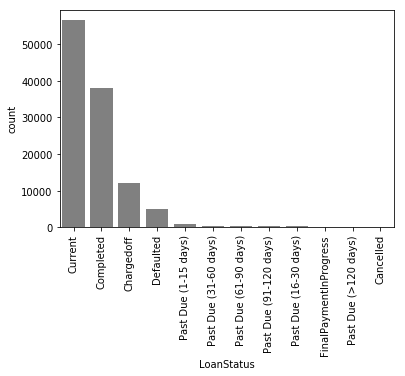

```python
# univariate plot of LoanStatus as a Categorical data, sorted by the highest freqquency
sns.countplot(df_loan['LoanStatus'], order = df_loan.LoanStatus.value_counts().index ,color = '0.5' )
plt.xticks(rotation = 90);
```

**LoanStatus** Comments:

- Almost all the data can be placed in the first four categories (Current, Completed, Chargedoff, Defaulted).
- Current category contains more loans than any others.

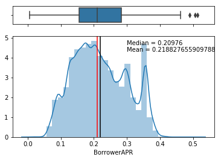

```python
# univariate plot of BorrowerAPR
# Median and Mean comparison
median_APR= df_loan.BorrowerAPR.median()
mean_APR= df_loan.BorrowerAPR.mean()

# Cut the window in 2 parts
f, (ax_box, ax_hist) = plt.subplots(2, sharex=True, gridspec_kw={"height_ratios": (.15, .85)})

# Add a graph in each part
sns.boxplot(df_loan["BorrowerAPR"], ax=ax_box)
#sns.distplot(df_loan["BorrowerAPR"], ax=ax_hist)

sns.distplot(df_loan['BorrowerAPR'],bins=30,kde=True).annotate('''Median = {}
Mean = {}'''.format(median_APR, mean_APR), (0.3,4.3))
plt.axvline(x=median_APR, color='red')
plt.axvline(x=mean_APR, color='black');

# Remove x axis name for the boxplot
ax_box.set(xlabel='');
```

- All BorrowerAPR values larger than 0.45 can be considered as outliers, based on the Box plot
- Mean and Median are very close to each other, Mean is slightly larger than Median
- It is a slightly right skewed distribution with a spike around 0.35

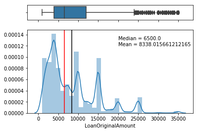

```python
# univariate plot of LoanOriginalAmount
# Median and Mean comparison
median_LOA= df_loan.LoanOriginalAmount.median()
mean_LOA= df_loan.LoanOriginalAmount.mean()

# Cut the window in 2 parts
f, (ax_box, ax_hist) = plt.subplots(2, sharex=True, gridspec_kw={"height_ratios": (.15, .85)})

# Add a graph in each part
sns.boxplot(df_loan["LoanOriginalAmount"], ax=ax_box)

sns.distplot(df_loan['LoanOriginalAmount'],bins=30,kde=True).annotate('''Median = {}
Mean = {}'''.format(median_LOA, mean_LOA), (20000,0.00012))
plt.axvline(x=median_LOA, color='red')
plt.axvline(x=mean_LOA, color='black');

# Remove x axis name for the boxplot
ax_box.set(xlabel='');
```

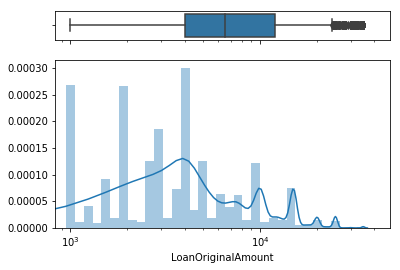

```python
# univariate plot of LoanOriginalAmount
# Cut the window in 2 parts
f, (ax_box, ax_hist) = plt.subplots(2, sharex=True, gridspec_kw={"height_ratios": (.15, .85)})

# Add a graph in each part
mybins=np.logspace(0, np.log(100), 100)
sns.boxplot(df_loan["LoanOriginalAmount"], ax=ax_box)
sns.distplot(df_loan["LoanOriginalAmount"], ax=ax_hist, bins=mybins)
mybins=np.logspace(0, np.log(100), 100)

# Logarithmic x axis scale
plt.xscale('log')


# Remove x axis name for the boxplot
ax_box.set(xlabel='');
```

**LoanOriginalAmount** Distribution Comments:

- All values larger than 25000 can be considered as outliers, based on the Box chart
- Mean and Median are quite different, Mean is larger than Median, indicating positive skewness
- Data shows positively skewed distribution with majority of datapoints falling between 1,000 and 10,000
- Based on the logarithmic view, data is quite spiky and it is very hard to call it as Unimodal or even Bimodal

## Bivariate Exploration

Above, we looked at the univariate distribution of three features in the **Prosper Loan** dataset: LoanStatus, BorrowerAPR and LoanOriginalAmount. Here, we'll investigate relationships between pairs of these variables, particularly how each of them relate to the three above mentioned features.

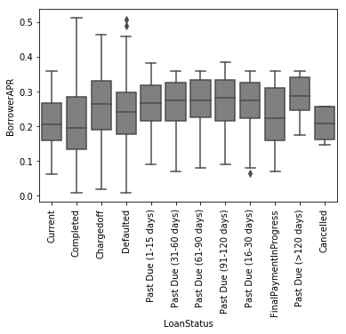

```python
# BorrowerAPR variation for each LoanStatus category, arranged by maximum frequency of LoanStatus categories
sns.boxplot(data=df_loan, x='LoanStatus', y='BorrowerAPR', color='0.5', order=df_loan.LoanStatus.value_counts().index)
plt.xticks(rotation=90);
```

**BorrowerAPR for LoanStatus categories** insights:

- Considering the bar chart from univariate exploration of LoanStatus, we know that major LoanStatus categories are established to be Current, Completed, Chargedoff and Defaulted. We use the same order to focus on the characteristics of these major groups.
- Interestingly enough, mean values of BrrowerAPR for Current, Completed LoanStatus categories are significantly lower than Chargedoff and Defaulted categories.

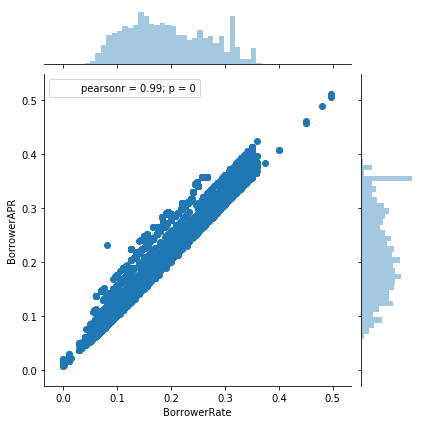

```python
# BorrowerAPR variation versus BorrowRate
sns.jointplot('BorrowerRate','BorrowerAPR',data=df_loan).annotate(stats.pearsonr);
```

**BorrowerAPR vs. BorrowerRate** insight:

- BorrowAPR is related to Borrower rate.
- There is a strong positive relationship between the 2 variables. Pearson r of 0.99 is indicative of this fact.

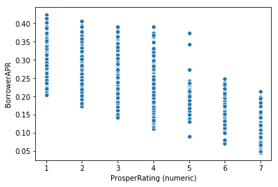

```python
# BorrowerAPR variation versus ProsperRating (numeric)'

sns.scatterplot(y='BorrowerAPR', x='ProsperRating (numeric)', data=df_loan);
```

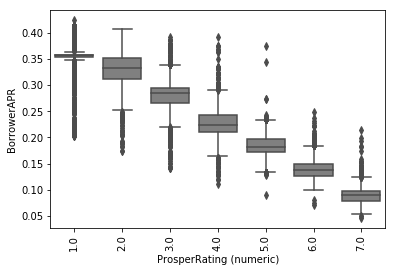

```python
# BorrowerAPR variation for each ProsperRating (numeric) category
sns.boxplot(data=df_loan, x='ProsperRating (numeric)', y='BorrowerAPR', color='0.5')
plt.xticks(rotation=90);
```

**BorrowerAPR vs. ProsperRating (numeric)** insight:

- BorrowAPR is related to ProsperRating (numeric).
- There is a negative relationship between the 2 variables. It means when the ProsperRating (numeric) variable increases, the BorrowerAPR decreases.

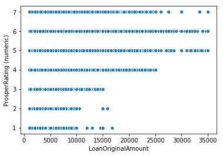

```python
# LoanOriginalAmount variation for each ProsperRating (numeric) category
sns.scatterplot(x='LoanOriginalAmount', y='ProsperRating (numeric)', data=df_loan);
```

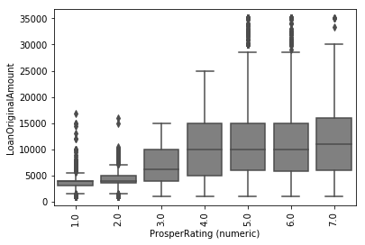

```python
# LoanOriginalAmount variation for each ProsperRating (numeric) category
sns.boxplot(data=df_loan, x='ProsperRating (numeric)', y='LoanOriginalAmount', color='0.5')
plt.xticks(rotation=90);
```

**ProsperRating (numeric) and LoanOriginalAmount** relationship:

- LoanOriginalAmount is related to ProsperRating (numeric).
- the lower `ProsperRating (numeric)` are associated with lower `LoanOriginalAmount`.
- there seem to be 3 distinct groups among the data based on above plot:
  - `ProsperRating (numeric)` of 1 and 2: these have the lowest `LoanOriginalAmount`, than is less than 5,000.
  - `ProsperRating (numeric)` of 3: this group has a medium `LoanOriginalAmount` of about 6,000.
  - `ProsperRating (numeric)` of bigger than 3: this group received `LoanOriginalAmount` of more than 10,000.

## Multivariate Exploration

So far, we looked at various univariate and bivariate relationships. in the following section, we will look into a few multivariate plots, trying extract more information from our dataset.

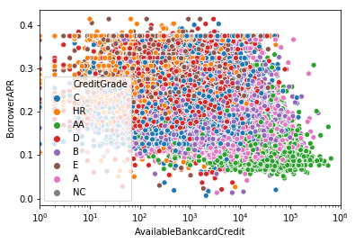

```python
# BorrowerAPR versus AvailableBankcardCredit for different CreditGrades


sns.scatterplot(y='BorrowerAPR', x='AvailableBankcardCredit', data=df_loan,
                hue='CreditGrade');
plt.xscale('log')
plt.xlim(1, 1000000);
```

**BorrowerAPR versus AvailableBankcardCredit for different CreditGrades** :

- There is a very large variation in the BorrowerAPR versus AvailableBankcardCredit. Using the logarithmic scale and categorising based off CreditGrade , creates more insight into the data.
- Although the plot is a little crowded, we can see that similar CreditGrades are clustered near each other.
- Also, we can see that `HR`, `D` and `E` categories are leaning towards the upper left of the chart, having higher BorrowerAPR while better CreditGrade of `AA` occupies the bottom right corner of the chart which is associated with the lowest possible BorrowerAPR

```python
# creating a pivot table to analyse multiple variables with a heatmap

pivot_table=df_loan.pivot_table(values='BorrowerAPR',index='EmploymentStatus',columns='ProsperRating (numeric)')
pivot_table
```

| ProsperRating (numeric) EmploymentStatus | 1.0 | 2.0 | 3.0 | 4.0 | 5.0 | 6.0 | 7.0 |
| --- | --- | --- | --- | --- | --- | --- | --- |
| Employed | 0.356704 | 0.328767 | 0.279917 | 0.225855 | 0.184561 | 0.140456 | 0.090363 |
| Full-time | 0.354274 | 0.343035 | 0.285567 | 0.229962 | 0.176361 | 0.128444 | 0.088291 |
| Not employed | 0.355192 | 0.342540 | 0.295956 | 0.250451 | 0.198343 | 0.147728 | 0.118158 |
| Other | 0.356180 | 0.326583 | 0.275895 | 0.226814 | 0.184360 | 0.142104 | 0.090502 |
| Part-time | 0.360652 | 0.339804 | 0.281258 | 0.225392 | 0.168737 | 0.124777 | 0.088034 |
| Retired | 0.353917 | 0.353557 | 0.286706 | 0.232628 | 0.177576 | 0.126503 | 0.091379 |
| Self-employed | 0.354106 | 0.331786 | 0.281131 | 0.222380 | 0.180615 | 0.138788 | 0.089877 |

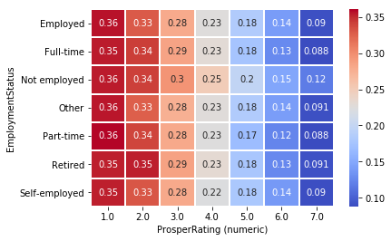

```python
# Heatmap frop the pivot table
sns.heatmap(pivot_table,cmap='coolwarm'
            ,linecolor='white',linewidths=1, annot=True);
```

**Learning from multivariate heatmap** :

- There is a general trend from left to right of the heatmap, increasing values of `BorrowerAPR` by decreasing `ProsperRating (numeric)`
- While there is not a huge vertical variation of values inside each ProsperRating (numeric) category, `Not employed` group stands out by showing a commonly higher `BorrowerAPR` than other employmentStatus

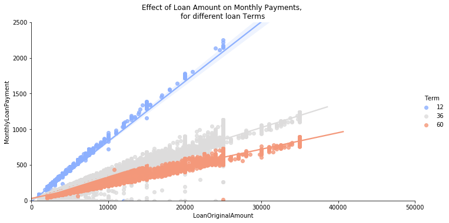

```python
# Scatter plot of Loan Amount on Monthly Payments,for different loan Terms

sns.lmplot(y='MonthlyLoanPayment',x='LoanOriginalAmount',data=df_loan, hue = 'Term', palette='coolwarm'
           ,aspect=2);
plt.ylim(0,2500)
plt.xlim(0,50000)
plt.title('''Effect of Loan Amount on Monthly Payments,
for different loan Terms''');
```

- There is a strong positive linear relationship between `LoanOriginalAmount` and `MonthlyLoanPayment` for each different `Term` category
- As expected, higher LoanOriginalAmount increases the MonthlyLoanPayment.
- The shorter is the term of Loan, the higher becomes the MonthlyLoanPayment